# Regresión Logística surgery

Leonardo Madsen

15/6/2021

# Actividad final tema 4: Regresión Logística

El objetivo es investigar la influencia de posibles variables explicativas en el riesgo de complicaciones post-operatorias en pacientes con problemas pulmonares. Para ello se pide analizar los df usando un modelo logístico adecuado.

df: surgery.txt Variables explicativas:

• age: Edad del paciente en años

• surgtype: Tipo de cirugía (1= Orthopedic, 2= Gynecological, 3= Abdominal)

• blocking: Agente bloqueante neuromuscular (1= Pancuronium (P), 2= Vecuronium (V), 3= Atracurium (A))

• longact: Agente blanqueante neuromuscular codificado en función de la actividad a largo plazo (0= No (V,A), 1= Si (P), (ver codificación de la variable anterior)

• duration: Duración de la operación en minutos

• tofratio: La razón T4/T1 en un test de estimulación train − of − four (TOF)

*Variable respuesta:* Y =complicación: Â ¿El paciente experimenta complicación pulmonar? 0: No, 1: Si.

Fuente: Regression with Linear Predictors, Andersen, Per Kragh, Skovgaard, Lene Theil, Springer (2010)

```r
df<- read.table("surgery.txt")
head(df)
```

```
##   age surgtype blocking longact duration tofratio complication
## 1  81        3        3       0      153     0.90            1
## 2  59        3        2       0      155     0.96            0
## 3  54        3        3       0      125     0.91            1
## 4  62        3        1       1      250     0.85            0
## 5  25        3        2       0      170     0.80            0
## 6  77        1        3       0      150     0.82            0
```

```r
df<- read.table("surgery.txt")
df$surgtype = factor(df$surgtype, labels = c("Orthopedic","Gynecological", "Abdominal"))
df$blocking = factor(df$blocking, labels = c("Pancuronium","Vecuronium", "Atracurium"))
df$longact = factor(df$longact, labels = c("No","Si"))
df$complication = factor(df$complication, labels = c("No","Si"))
head(df)
```

```
##   age   surgtype    blocking longact duration tofratio complication
## 1  81  Abdominal  Atracurium      No      153     0.90           Si
## 2  59  Abdominal  Vecuronium      No      155     0.96           No
## 3  54  Abdominal  Atracurium      No      125     0.91           Si
## 4  62  Abdominal Pancuronium      Si      250     0.85           No
## 5  25  Abdominal  Vecuronium      No      170     0.80           No
## 6  77 Orthopedic  Atracurium      No      150     0.82           No
```

## Seleccionar aleatoriamente el conjunto de entrenamiento. El 80 % de los df serán considerados para construir el modelo (training set). El resto de df 20 % (test set) sería considerado en la posterior evaluación del modelo y debe ser ignorado en la primera parte del estudio, es decir, no tener en cuenta en la construcción del modelo.

```r
set.seed(101) # semilla

sample <- sample.int(n = nrow(df), size = floor(.80*nrow(df)), replace = F)
train <- df[sample, ]
test  <- df[-sample, ]
```

## Usar un procedimiento secuencial para construir un modelo de regresión logística que permita explicar la variable respuesta a partir de la información dada por las variables explicativas.

Dado que la variable ‘longact’ depende de ‘blocking’ primero comprobamos si esta ultima es conveniente meterla en el modelo. Tambien comentar que no centro la edad ya que he probado a hacerlo y proporciona los mismos resultados.

```r
summary(glm(complication~ age+surgtype+blocking+duration+tofratio, family = binomial, data=df))
```

```
##
## Call:
## glm(formula = complication ~ age + surgtype + blocking + duration +
##     tofratio, family = binomial, data = df)
##
## Deviance Residuals:
##     Min       1Q   Median       3Q      Max
## -1.4239  -0.3516  -0.2273  -0.1401   2.8481
##
## Coefficients:
##                        Estimate Std. Error z value Pr(>|z|)
## (Intercept)           -5.593298   1.395070  -4.009 6.09e-05 ***
## age                    0.042792   0.011276   3.795 0.000148 ***
## surgtypeGynecological  0.521776   0.654539   0.797 0.425355
## surgtypeAbdominal      2.091029   0.485783   4.304 1.67e-05 ***
## blockingVecuronium    -0.245780   0.429194  -0.573 0.566878
## blockingAtracurium    -0.023393   0.439278  -0.053 0.957530
## duration               0.005814   0.002553   2.278 0.022754 *
## tofratio              -2.187635   1.234239  -1.772 0.076319 .
## ---
## Signif. codes:  0 '***' 0.001 '**' 0.01 '*' 0.05 '.' 0.1 ' ' 1
##
## (Dispersion parameter for binomial family taken to be 1)
##
##     Null deviance: 314.73  on 675  degrees of freedom
## Residual deviance: 257.49  on 668  degrees of freedom
## AIC: 273.49
##
## Number of Fisher Scoring iterations: 6
```

Vemos como ningunos de los niveles de ‘Blocking’ es significativo por lo que no entraria en el mdelo y por tanto la variable ‘longact’ tampoco lo haria.

```r
modelo= glm(complication~ age+surgtype+blocking+duration+tofratio, family = binomial, data=df)
modelo1=step(modelo)
```

```
## Start:  AIC=273.49
## complication ~ age + surgtype + blocking + duration + tofratio
##
##            Df Deviance    AIC
## - blocking  2   257.89 269.89
## <none>          257.49 273.49
## - tofratio  1   260.47 274.47
## - duration  1   262.59 276.59
## - age       1   273.64 287.64
## - surgtype  2   287.17 299.17
##
## Step:  AIC=269.89
## complication ~ age + surgtype + duration + tofratio
##
##            Df Deviance    AIC
## <none>          257.89 269.89
## - tofratio  1   261.71 271.71
## - duration  1   262.99 272.99
## - age       1   273.77 283.77
## - surgtype  2   287.40 295.40
```

```r
summary(modelo1)
```

```
##
## Call:
## glm(formula = complication ~ age + surgtype + duration + tofratio,
##     family = binomial, data = df)
##
## Deviance Residuals:
##     Min       1Q   Median       3Q      Max
## -1.4204  -0.3511  -0.2300  -0.1411   2.7933
##
## Coefficients:
##                        Estimate Std. Error z value Pr(>|z|)
## (Intercept)           -5.544673   1.387633  -3.996 6.45e-05 ***
## age                    0.042318   0.011233   3.767 0.000165 ***
## surgtypeGynecological  0.508743   0.654573   0.777 0.437033
## surgtypeAbdominal      2.079119   0.485171   4.285 1.82e-05 ***
## duration               0.005823   0.002556   2.278 0.022734 *
## tofratio              -2.304075   1.138304  -2.024 0.042957 *
## ---
## Signif. codes:  0 '***' 0.001 '**' 0.01 '*' 0.05 '.' 0.1 ' ' 1
##
## (Dispersion parameter for binomial family taken to be 1)
##
##     Null deviance: 314.73  on 675  degrees of freedom
## Residual deviance: 257.89  on 670  degrees of freedom
## AIC: 269.89
##
## Number of Fisher Scoring iterations: 6
```

Parece que el valor de ‘surgtype’= 2 no es significativo habria que hacer un estudio un poco mas incisivo en este typo de variable que dada su naturaleza es una de las variable de interes y que habria que saber como es su interacion con la variable ‘complication’ dado que el estudio se basa en el post operatorio y sus posibles complicaciones.

Comparamos los valores ‘surgtype’= 1 y ‘surgtype’= 2.

```r
str(df)
```

```
## 'data.frame':    676 obs. of  7 variables:
##  $ age         : int  81 59 54 62 25 77 66 41 46 86 ...
##  $ surgtype    : Factor w/ 3 levels "Orthopedic","Gynecological",..: 3 3 3 3 3 1 1 3 3 2 ...
##  $ blocking    : Factor w/ 3 levels "Pancuronium",..: 3 2 3 1 2 3 1 3 2 1 ...
##  $ longact     : Factor w/ 2 levels "No","Si": 1 1 1 2 1 1 2 1 1 2 ...
##  $ duration    : int  153 155 125 250 170 150 72 150 135 135 ...
##  $ tofratio    : num  0.9 0.96 0.91 0.85 0.8 0.82 0.6 0.98 0.84 0.79 ...
##  $ complication: Factor w/ 2 levels "No","Si": 2 1 2 1 1 1 1 1 1 1 ...
```

```r
summary(glm(complication~ age+surgtype+duration+tofratio, subset=which(surgtype==c("Orthopedic","Gynecological")), family = binomial, data=df))
```

```
##
## Call:
## glm(formula = complication ~ age + surgtype + duration + tofratio,
##     family = binomial, data = df, subset = which(surgtype ==
##         c("Orthopedic", "Gynecological")))
##
## Deviance Residuals:
##      Min        1Q    Median        3Q       Max
## -1.03235  -0.14776  -0.09758  -0.06303   2.58657
##
## Coefficients:
##                        Estimate Std. Error z value Pr(>|z|)
## (Intercept)           -3.353046   4.383018  -0.765  0.44427
## age                    0.052985   0.046322   1.144  0.25269
## surgtypeGynecological  1.297456   1.458162   0.890  0.37358
## duration               0.004243   0.008851   0.479  0.63169
## tofratio              -7.194299   2.599000  -2.768  0.00564 **
## ---
## Signif. codes:  0 '***' 0.001 '**' 0.01 '*' 0.05 '.' 0.1 ' ' 1
##
## (Dispersion parameter for binomial family taken to be 1)
##
##     Null deviance: 40.274  on 227  degrees of freedom
## Residual deviance: 29.312  on 223  degrees of freedom
## AIC: 39.312
##
## Number of Fisher Scoring iterations: 8
```

El modelo no seria adecuado. y las complicaciones dependerian de otras cosas.

Como veiamos en el modelo incial ‘surgtype’= 3 si es significativa lo de lo que podemos deducir que las operaciones tipo 1 y 2 podrian tener efecto parecido en la varaible ‘complications’

En conclusion dado que el estudio es sobre el post-operatorio no tendria sentido no tener en cuenta el tipo de cirugia, cierto es que parece que el tipo 2 (Gynecological), no parece ser significativo para el modelo el estudio precisa de ella para no desviarse del tema.

### Otras forma:

```r
modelo.full <-glm(complication~ age+surgtype+blocking+duration+tofratio+longact, data = df,family = binomial)
modelo.inicial <-glm(complication ~ 1, data = df, family = binomial)
modelo.stp <-stepAIC(modelo.inicial, scope =list(upper = modelo.full), direction = "both")
```

```
## Start:  AIC=316.73
## complication ~ 1
##
##            Df Deviance    AIC
## + surgtype  2   286.35 292.35
## + age       1   297.89 301.89
## + duration  1   303.93 307.93
## + tofratio  1   308.13 312.13
## <none>          314.73 316.73
## + longact   1   313.01 317.01
## + blocking  2   313.01 319.01
##
## Step:  AIC=292.35
## complication ~ surgtype
##
##            Df Deviance    AIC
## + age       1   267.87 275.87
## + duration  1   278.76 286.76
## + tofratio  1   280.02 288.02
## <none>          286.35 292.35
## + longact   1   284.84 292.84
## + blocking  2   284.84 294.84
## - surgtype  2   314.73 316.73
##
## Step:  AIC=275.87
## complication ~ surgtype + age
##
##            Df Deviance    AIC
## + duration  1   261.71 271.71
## + tofratio  1   262.99 272.99
## <none>          267.87 275.87
## + longact   1   266.35 276.35
## + blocking  2   266.26 278.26
## - age       1   286.35 292.35
## - surgtype  2   297.89 301.89
##
## Step:  AIC=271.71
## complication ~ surgtype + age + duration
##
##            Df Deviance    AIC
## + tofratio  1   257.89 269.89
## <none>          261.71 271.71
## + longact   1   260.58 272.58
## + blocking  2   260.47 274.47
## - duration  1   267.87 275.87
## - age       1   278.76 286.76
## - surgtype  2   291.11 297.11
##
## Step:  AIC=269.89
## complication ~ surgtype + age + duration + tofratio
##
##            Df Deviance    AIC
## <none>          257.89 269.89
## - tofratio  1   261.71 271.71
## + longact   1   257.74 271.74
## - duration  1   262.99 272.99
## + blocking  2   257.49 273.49
## - age       1   273.77 283.77
## - surgtype  2   287.40 295.40
```

```r
summary(modelo.stp)
```

```
##
## Call:
## glm(formula = complication ~ surgtype + age + duration + tofratio,
##     family = binomial, data = df)
##
## Deviance Residuals:
##     Min       1Q   Median       3Q      Max
## -1.4204  -0.3511  -0.2300  -0.1411   2.7933
##
## Coefficients:
##                        Estimate Std. Error z value Pr(>|z|)
## (Intercept)           -5.544673   1.387633  -3.996 6.45e-05 ***
## surgtypeGynecological  0.508743   0.654573   0.777 0.437033
## surgtypeAbdominal      2.079119   0.485171   4.285 1.82e-05 ***
## age                    0.042318   0.011233   3.767 0.000165 ***
## duration               0.005823   0.002556   2.278 0.022734 *
## tofratio              -2.304075   1.138304  -2.024 0.042957 *
## ---
## Signif. codes:  0 '***' 0.001 '**' 0.01 '*' 0.05 '.' 0.1 ' ' 1
##
## (Dispersion parameter for binomial family taken to be 1)
##
##     Null deviance: 314.73  on 675  degrees of freedom
## Residual deviance: 257.89  on 670  degrees of freedom
## AIC: 269.89
##
## Number of Fisher Scoring iterations: 6
```

Como podemos ver con la funcion StepAIC podemos secuenciar la forma de encontrar el mejor modelo.

## Estudio de la bondad de ajuste. Se requiere una explicación de los resultados obtenidos en los siguientes apartados:

### a) Contraste de regresión. Resolver mediante el test de razón de verosimilitudes

```r
Anova(modelo1)
```

```
## Analysis of Deviance Table (Type II tests)
##
## Response: complication
##          LR Chisq Df Pr(>Chisq)
## age       15.8824  1  6.740e-05 ***
## surgtype  29.5134  2  3.902e-07 ***
## duration   5.1030  1    0.02388 *
## tofratio   3.8197  1    0.05065 .
## ---
## Signif. codes:  0 '***' 0.001 '**' 0.01 '*' 0.05 '.' 0.1 ' ' 1
```

### b) Contraste de regresión. Resolver mediante el test de Hosmer-Lemeshow.

```r
hosmerlem <-function(y, yhat, g = 10){
  cutyhat1 =cut(yhat, breaks =quantile(yhat, probs =seq(0, 1, 1/g)), include.lowest = TRUE)
  obs =xtabs(cbind(1 - y, y) ~ cutyhat1)
  expect =xtabs(cbind(1 - yhat, yhat) ~ cutyhat1)
  chisq.C =sum((obs - expect)^2/expect)
  P.C = 1 -pchisq(chisq.C, g - 2)
  cutyhat2 =cut(yhat, breaks = g, include.lowest = TRUE)
  obs =xtabs(cbind(1 - y, y) ~ cutyhat2)
  expect =xtabs(cbind(1 - yhat, yhat) ~ cutyhat2)
  chisq.H =sum((obs - expect)^2/expect)
  P.H = 1 -pchisq(chisq.H, g - 2)
  res <-data.frame(c(chisq.C, P.C),c(chisq.H, P.H))
  colnames(res) <-c("Hosmer-Lemeshow C statistic", "Hosmer-Lemeshow H statistic")
  rownames(res) <-c("X-squared", "p.value")
  return(res)
  }
```

```r
hosmerlem(df$complication,fitted.values(modelo1))
```

```
##           Hosmer-Lemeshow C statistic Hosmer-Lemeshow H statistic
## X-squared                         676                         NaN
## p.value                             0                         NaN
```

### c) Calcular el coeficiente $R^{2}$ de Nagelkerke.

```r
LR <- modelo1$null.deviance - modelo1$deviance
N <-sum(weights(modelo1))
RsqrCN <- 1 -exp(-LR/N)
L0.adj <-exp(-modelo1$null.deviance/N)
RsqrNal <- RsqrCN/(1 - L0.adj)
RsqrNal
```

```
## [1] 0.2166705
```

Pese a que globalmente el modelo se ajusta a los df parece que no tiene un buen ajuste.

### d) Construir la curva ROC y calcular el área bajo la curva.

```r
pred <-prediction(fitted.values(modelo1), df$complication)
```

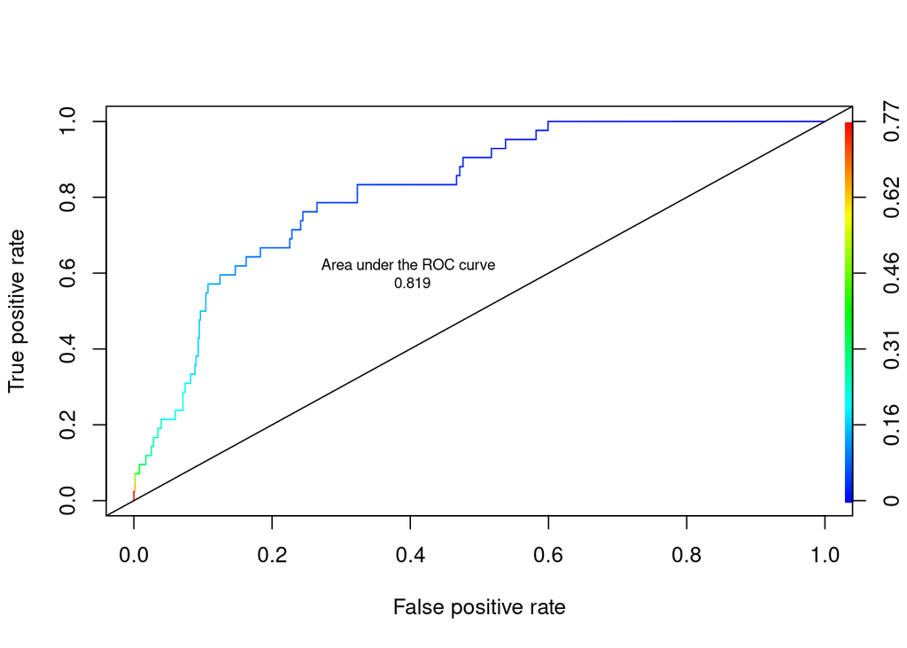

```r
# auc : Area under curve
AUC <-performance(pred, "auc")
perf2 <-performance(pred, "tpr", "fpr")
plot(perf2, colorize = TRUE)
abline(a = 0, b = 1)
text(0.4, 0.6,paste(AUC@y.name, "\n",round(unlist(AUC@y.values), 3)), cex = 0.7)
```

### e) Obtener el punto de corte óptimo, $p_{opt}$

```r
#pred <-prediction(fitted.values(modelo1), df$complication)
perf1 <-performance(pred, measure = "acc")
# el punto de corte que maximiza'acc'es
(posicion.max <-sapply(perf1@y.values, which.max))
```

```
## [1] 5
```

Punto de corte:

```r
(punto.corte <-sapply(perf1@x.values, "[", posicion.max))
```

```
##       125
## 0.4857247
```

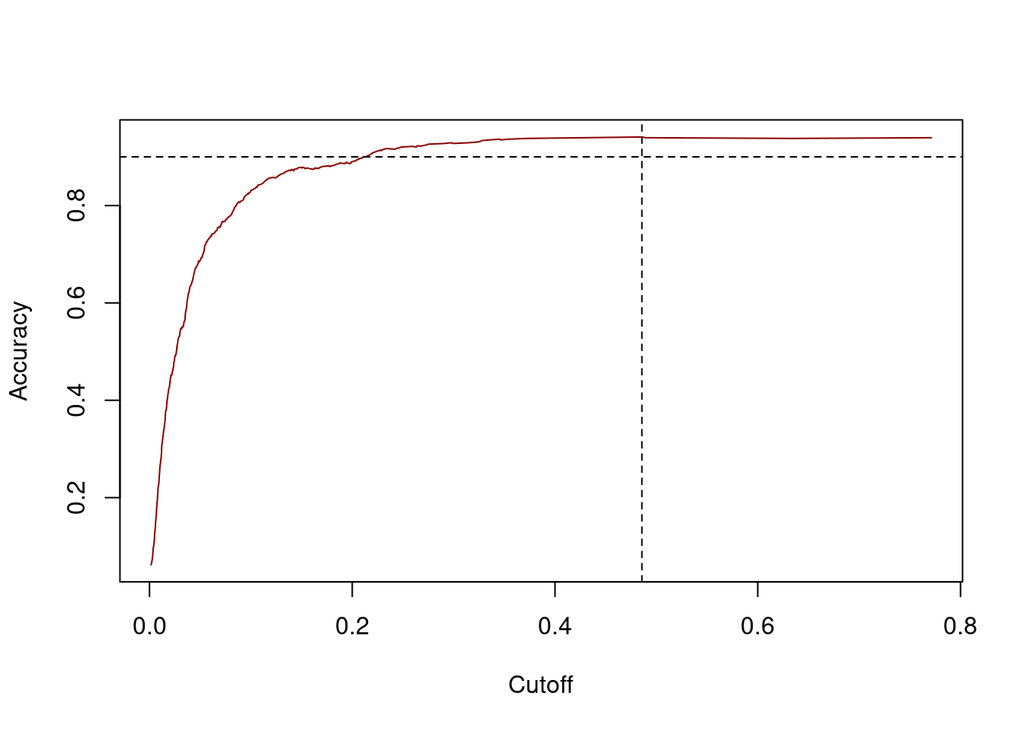

```r
plot(perf1, col = "darkred")
abline(h = 0.9, lty = 2)
abline(v = punto.corte, lty = 2)
```

### f) Cuantifica la capacidad predictiva del modelo en el conjunto de entrenamiento.

```r
pred.modelo.stp <-prediction(fitted.values(modelo.stp), df$complication)
perf.modelo.stp <-performance(pred.modelo.stp, "tpr", "fpr")
AUC.modelo.stp <-performance(pred.modelo.stp, "auc")
AUC.modelo.stp@y.values
```

```
## [[1]]
## [1] 0.8190626
```

Vemos que el modelo tiene ua capacidad predictiva del 82%.

## Modelo definitivo.

### a) Presentación de la ecuación del modelo en términos de logits, de odds y de probabilidad.

```r
summary(modelo1)
```

```
##
## Call:
## glm(formula = complication ~ age + surgtype + duration + tofratio,
##     family = binomial, data = df)
##
## Deviance Residuals:
##     Min       1Q   Median       3Q      Max
## -1.4204  -0.3511  -0.2300  -0.1411   2.7933
##
## Coefficients:
##                        Estimate Std. Error z value Pr(>|z|)
## (Intercept)           -5.544673   1.387633  -3.996 6.45e-05 ***
## age                    0.042318   0.011233   3.767 0.000165 ***
## surgtypeGynecological  0.508743   0.654573   0.777 0.437033
## surgtypeAbdominal      2.079119   0.485171   4.285 1.82e-05 ***
## duration               0.005823   0.002556   2.278 0.022734 *
## tofratio              -2.304075   1.138304  -2.024 0.042957 *
## ---
## Signif. codes:  0 '***' 0.001 '**' 0.01 '*' 0.05 '.' 0.1 ' ' 1
##
## (Dispersion parameter for binomial family taken to be 1)
##
##     Null deviance: 314.73  on 675  degrees of freedom
## Residual deviance: 257.89  on 670  degrees of freedom
## AIC: 269.89
##
## Number of Fisher Scoring iterations: 6
```

```r
modelo.stp
```

```
##
## Call:  glm(formula = complication ~ surgtype + age + duration + tofratio,
##     family = binomial, data = df)
##
## Coefficients:
##           (Intercept)  surgtypeGynecological      surgtypeAbdominal
##             -5.544673               0.508743               2.079119
##                   age               duration               tofratio
##              0.042318               0.005823              -2.304075
##
## Degrees of Freedom: 675 Total (i.e. Null);  670 Residual
## Null Deviance:       314.7
## Residual Deviance: 257.9     AIC: 269.9
```